# Fitting AR(p) 2

[Nao Mimoto](https://nmimoto.github.io/) - [Dept. of Statistics](http://www.uakron.edu/stat/) : [The University of Akron](http://www.uakron.edu)

[TS Class Web Page](https://nmimoto.github.io/477/index.html) – [R resource page](https://nmimoto.github.io/R/index.html)

# 1. De-mean or Not

- Theoretically, AR($1$) has mean of 0.
  $$X_t = \phi X_{t-1} + e_t \hspace10mm e_t \sim WN(0,\sigma^2).$$
- If the observed series looks like AR($1$) with constant mean, our model is
  $$Y_t = \mu + X_t,
  \hspace10mm \mbox{ where } \mu
  \mbox{ is a constant and $X_t$ is AR(p).}$$
- That means, $Y_t$ has a mean of $\mu$, and we need to de-mean (de-trend) by letting
  $$\hat X_t = Y_t - \hat \mu = Y_t - \bar Y.$$
  before modeling $\hat X_t$ with zero-mean AR($1$).
- **include.mean=TRUE** is default in **Arima()** of **forecast** package.
- If you use **include.mean=FALSE** option, that means our model is
  $$Y_t = X_t.$$
  and $Y_t$ is believed to have mean of $0$. $Y_t$ is directly being modeled with zero-mean AR(p) model.

## Example: De-mean or not

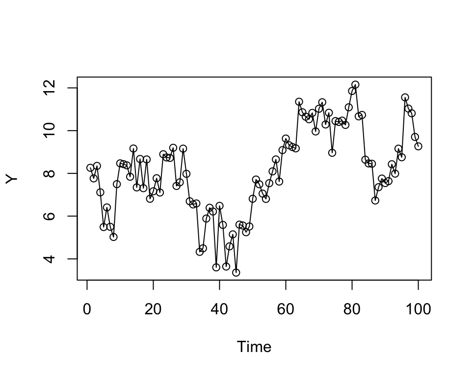

```r
  set.seed(3563)
  Y    <- arima.sim(list(ar = c(.6, .3) ), 100 )  + 8.5
  plot(Y, type="o")
```

```r
  mean(Y)
```

```
## [1] 8.11923
```

```r
  library(forecast)              # install.packages("forecast") if you haven't

  Fit01 <- Arima(Y, order=c(2,0,0))                             # fit AR(2) to Y

  Fit02 <- Arima(Y, order=c(2,0,0), include.mean=FALSE)         # don't de-mean

  Fit03 <- Arima(Y-mean(Y), order=c(2,0,0), include.mean=FALSE) # de-mean by hand
```

- **Fit01** is fitting AR(2) with mean using MLE.
- **Fit02** is fitting AR(2) with zero-mean using MLE.
- **Fit03** is fitting AR(2) with zero-mean after you demean by hand.

# 2. Order Selection of AR(p)

- 1. ACF and PACF
- 2. AIC and log-likelihood
- 3. Parameter Significance

## a. ACF and PACF

- ACF of AR(p) tails off
- PACF of AR(P) cuts off at lag $p$.
- Theoretical value of PACF($h$) are $\phi_h$.

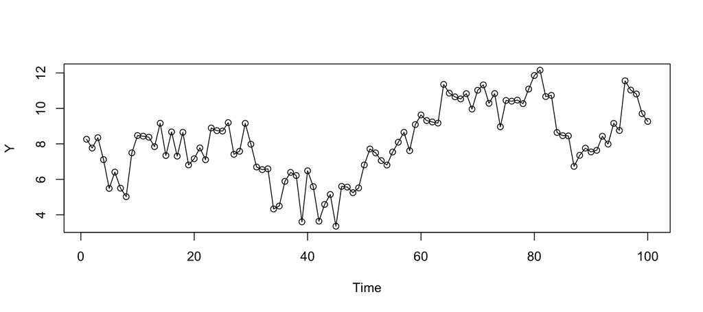

```r
  plot(Y, type="o")
```

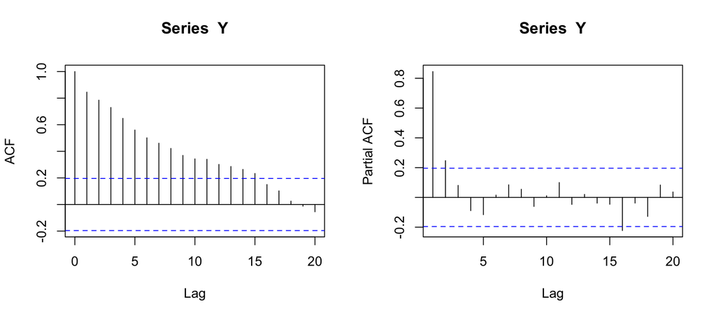

```r
  layout(matrix(1:2, 1, 2))  # two plots side by side
  acf(Y)                     # plot sample ACF
  pacf(Y)                    # plot sample PACF
```

```r
  layout(1)                  # return to 1 plot layout
```

## Example: AIC Simulation Study

If we use AIC all the time, what is the probability we end up with correct $p$?

- Set $p=2$. Generate simulated AR(2).
- Use **auto.arima(Y)** and search for best $p$ by using Minimum AIC.
- Repeat 1000 times. How many time do we end up with right $p$?

```r
  #- Simulation Study of choosing p by AIC
  Result <- 0
  for (i in 1:1000){
    Y    <- arima.sim(list(ar = c(.6, .3) ), 100 )  + 8.5
    Fit7 <- auto.arima(Y, d=0, max.q=0)        # find AR(p) by AIC
    Result[i] <- length(Fit7$model$phi)        # save value of p chosen
  }
  head(Result, 100)                       # first 100 p
```

```
##   [1] 2 2 2 2 2 2 2 2 2 2 2 2 2 1 2 2 2 2 1 2 2 2 2 2 2 2 2 1 2 2 5 2 2 2 2 2 1 2 2 2 2 1
##  [43] 2 2 2 2 2 2 2 2 2 2 2 2 2 2 1 2 2 2 2 2 5 2 2 2 2 2 1 2 2 3 2 2 2 2 2 3 2 1 3 1 2 2
##  [85] 1 2 2 3 2 2 1 1 3 2 4 2 2 1 2 2
```

```r
  mean(Result==2)                         # propotion of times p=2
```

```
## [1] 0.786
```

## c. Parameter Significance

- After $p$ was suggested by AIC, test the pameter estimate for significance using large-sample 95% CI. i.e. $\hat p \pm 2 SE$

## Example: When AIC fails

If we use AIC all the time, what is the probability we end up with correct $p$?

```r
  #- Choosing p by AIC, stop if p > 2
  Result <- 0
  for (i in 1:1000){
    Y    <- arima.sim(list(ar = c(.6, .3) ), 100 )  + 8.5
    Fit7 <- auto.arima(Y, d=0, max.q=0)        # find AR(p) by AIC
    Result[i] <- length(Fit7$model$phi)        # save value of p chosen
    if (Result[i] > 2){
      print( length(Fit7$model$phi) )
      break
    }
  }
```

```
## [1] 3
```

```r
  arima(Y, order=c(3,0,0))      # fit AR(3)
```

```
##
## Call:
## arima(x = Y, order = c(3, 0, 0))
##
## Coefficients:
##          ar1     ar2     ar3  intercept
##       0.5252  0.1866  0.2071     8.6497
## s.e.  0.0973  0.1089  0.0971     0.9954
##
## sigma^2 estimated as 0.8743:  log likelihood = -135.99,  aic = 281.98
```

```r
  arima(Y, order=c(2,0,0))      # fit AR(2)
```

```
##
## Call:
## arima(x = Y, order = c(2, 0, 0))
##
## Coefficients:
##          ar1     ar2  intercept
##       0.5917  0.3092     8.7179
## s.e.  0.0941  0.0945     0.8721
##
## sigma^2 estimated as 0.9149:  log likelihood = -138.21,  aic = 284.42
```

## Example: order selection a-b-c

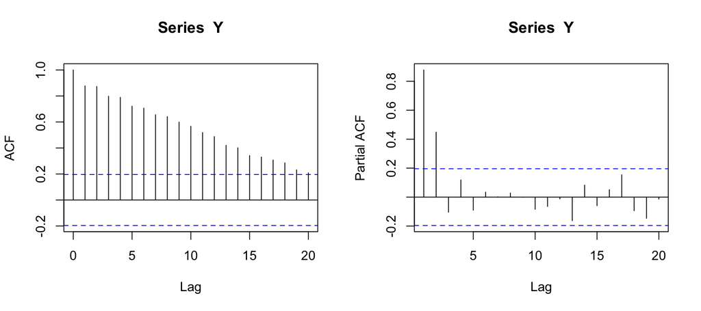

```r
  set.seed(4772)
  Y    <- arima.sim(list(ar = c(.6, .3) ), 100 ) + 8.5     # simulate AR(2)

  #- 1. ACF and PACF
  layout(matrix(1:2, 1, 2))             # two plots side by side
  acf(Y)                                # plot sample ACF of Y
  pacf(Y)                               # plot sample PACF of Y
```

```r
  layout(1)                             # return to 1 plot layout

  #- 2. AIC
  Fit8 <- auto.arima(Y)                 # Fit AR(p). Find best p by AIC
  Fit8
```

```
## Series: Y
## ARIMA(1,1,0)
##
## Coefficients:
##           ar1
##       -0.4947
## s.e.   0.0878
##
## sigma^2 estimated as 0.8124:  log likelihood=-129.83
## AIC=263.65   AICc=263.78   BIC=268.84
```

```r
  Fit8$aic                              # AIC for the chosen model
```

```
## [1] 263.6525
```

```r
  #- 3. Parameter Significance
  Fit9 <- Arima(Y, order=c(2,0,0) )     # fit AR(2)
  Fit9
```

```
## Series: Y
## ARIMA(2,0,0) with non-zero mean
##
## Coefficients:
##          ar1     ar2    mean
##       0.4658  0.4581  7.0107
## s.e.  0.0885  0.0888  0.9947
##
## sigma^2 estimated as 0.8042:  log likelihood=-130.38
## AIC=268.76   AICc=269.18   BIC=279.18
```

```r
  Fit9$model$phi                        # phi1 hat and phi2 hat
```

```
## [1] 0.4658033 0.4581181
```

```r
  sqrt(diag(Fit9$var.coef))             # SE for phi (same as output)
```

```
##        ar1        ar2  intercept
## 0.08850786 0.08881952 0.99465511
```

# 3. Residual Analysis of AR(p)

## Example: Residual Analysis

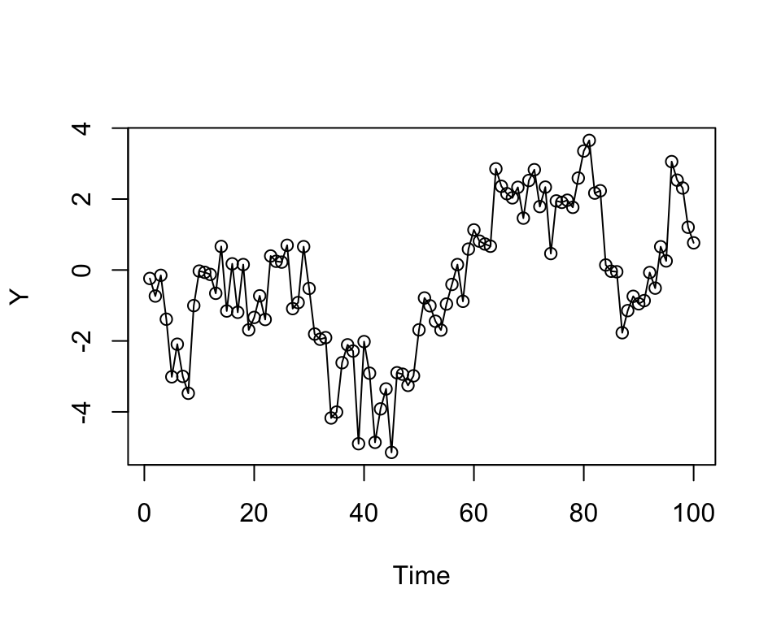

```r
  set.seed(3563)
  Y    <- arima.sim(list(ar = c(.6, .3) ), 100 )
  plot(Y, type="o")
```

```r
  Fit09 <- Arima(Y, order=c(2,0,0), include.mean=FALSE)          # fit AR(2)
  Fit09
```

```
## Series: Y
## ARIMA(2,0,0) with zero mean
##
## Coefficients:
##          ar1     ar2
##       0.6279  0.2530
## s.e.  0.0958  0.0959
##
## sigma^2 estimated as 1.088:  log likelihood=-145.78
## AIC=297.55   AICc=297.8   BIC=305.37
```

```r
  res   <- Fit09$resid                       # extract the residuals
  res
```

```
## Time Series:
## Start = 1
## End = 100
## Frequency = 1
##   [1] -0.125120376 -0.516514985  0.371576940 -1.107009588 -2.102633877  0.149898985
##   [7] -0.924339580 -1.063014563  1.937233661  1.479867875  0.206238128 -0.074583443
##  [13] -0.562946698  1.107662240 -1.406661721  0.732666286 -1.009395211  0.857768994
##  [19] -1.483114286 -0.315466261  0.538839192 -0.600311196  1.455587318  0.350725689
##  [25] -0.032241007  0.496018048 -1.582838152 -0.410956217  1.509867542 -0.700668997
##  [31] -1.645742613 -0.687316378 -0.224103502 -2.481482569 -0.903373124  0.957356315
##  [37]  0.545280800 -0.299999646 -2.929796634  1.634819088 -0.402916836 -2.521157208
##  [43] -0.129219223  0.335421656 -2.046475081  1.180352070  0.182626415 -0.676085651
##  [49] -0.197933089  1.009032404  1.026029210 -0.088155778 -0.611498470 -0.531325661
##  [55]  0.469679768  0.624261534  0.651314043 -0.876104882  1.104851743  0.983531787
##  [61] -0.044519851 -0.064338560  0.004113708  2.246773379  0.398652275 -0.051180491
##  [67]  0.085646365  0.509691218 -0.516394560  1.015704897  0.874144891 -0.626109628
##  [73]  0.498649583 -1.456258337  1.065650387  0.567119069  0.277276538  0.048982999
##  [79]  0.984373577  1.280681352  0.891782794 -0.975160790 -0.051029099 -1.809801283
##  [85] -0.689138734 -0.063599760 -1.728563304 -0.022074558  0.424939853 -0.198056122
##  [91] -0.077164248  0.712087762 -0.248736398  0.995859847 -0.027582447  2.729472001
##  [97]  0.550102057 -0.052067553 -0.887269883 -0.575951928
```

```r
  Y[3]-Fit09$model$phi[1]*Y[2] - Fit09$model$phi[2]*Y[1]
```

```
## [1] 0.3715769
```

```r
  Y[4]-Fit09$model$phi[1]*Y[3] - Fit09$model$phi[2]*Y[2]
```

```
## [1] -1.10701
```

```r
  Y[5]-Fit09$model$phi[1]*Y[4] - Fit09$model$phi[2]*Y[3]
```

```
## [1] -2.102634
```

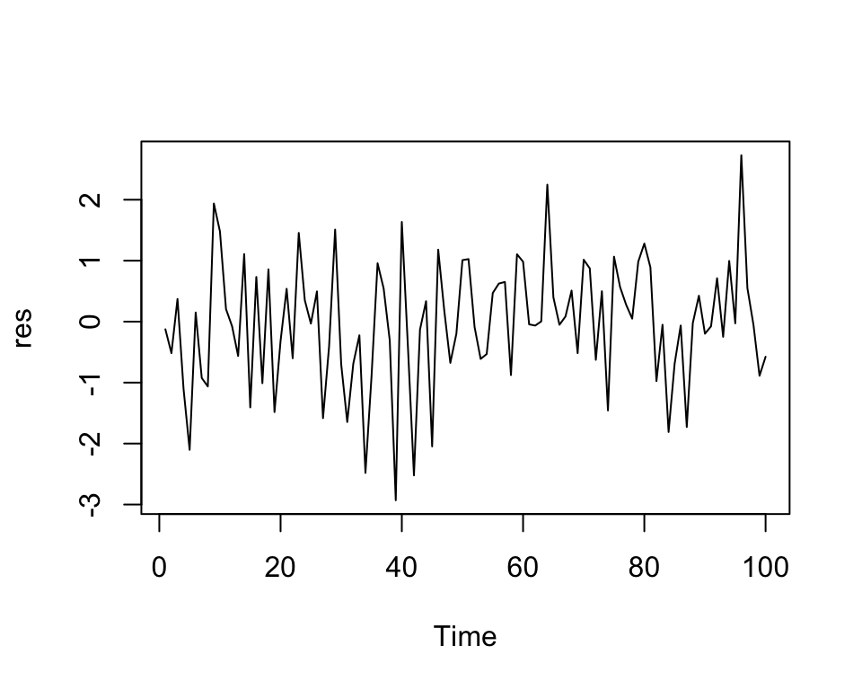

```r
  plot(res)
```

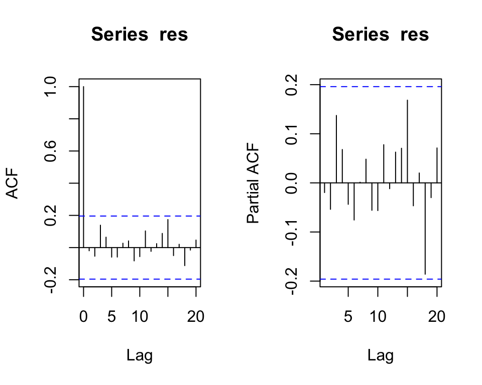

```r
  # Check acf + pacf of residuals
  layout(matrix(1:2, 1,2))                   # 2 plots side by side
  acf(res)
  pacf(res)
```

```r
  layout(1)
```

# 4. Example: Dow Jones 1972

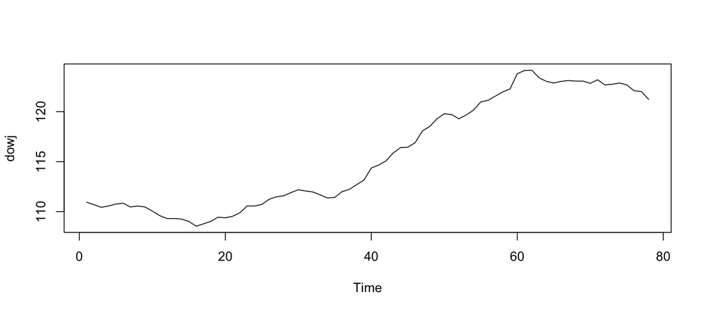

```r
  # read in daily Dow Jones data from my website
  D  <- read.csv("https://nmimoto.github.io/datasets/dowj.csv")
  D1 <- ts(D, start=c(1,1), freq=1)   # turn the data into TS object
  plot(D1)
```

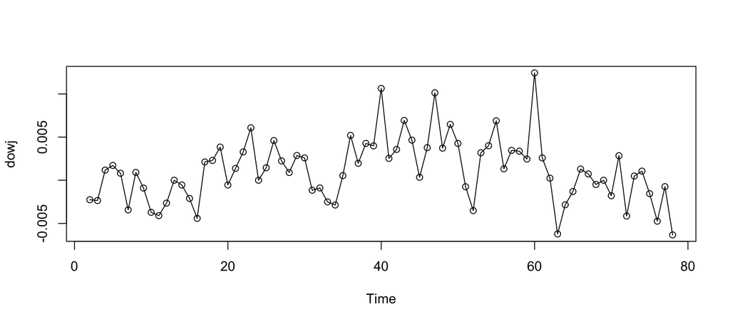

```r
  Y <- diff(log(D1))                  # Take log-difference
  plot(Y, type='o')
```

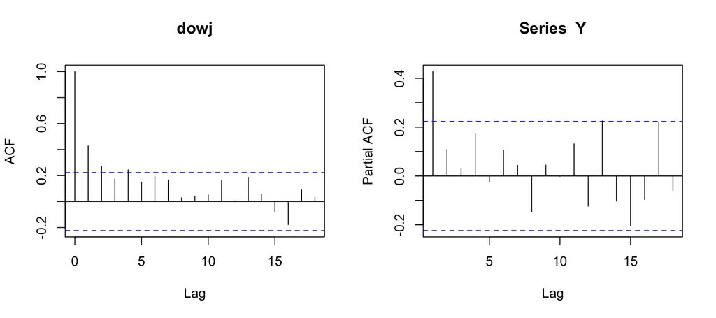

```r
  layout(matrix(1:2, 1,2))            # 2 plots side by side
  acf(Y)
  pacf(Y)
```

```r
  layout(1)                           # reset the layout


  Fit11 <- auto.arima(Y, d=0, max.q=0)      # Fit AR(p). Uses AIC to look for best p
  Fit11                                     # see the summary of fit
```

```
## Series: Y
## ARIMA(1,0,0) with zero mean
##
## Coefficients:
##          ar1
##       0.5042
## s.e.  0.0996
##
## sigma^2 estimated as 1.094e-05:  log likelihood=330.89
## AIC=-657.78   AICc=-657.62   BIC=-653.09
```

```r
  sqrt( diag(Fit11$asy.var.coef) )                # SE of the estimator
```

```
## <0 x 0 matrix>
```

```r
  Fit12 <- Arima(Y, order=c(2,0,0))         # force fit AR(2)
  Fit12
```

```
## Series: Y
## ARIMA(2,0,0) with non-zero mean
##
## Coefficients:
##          ar1     ar2   mean
##       0.4021  0.1158  1e-03
## s.e.  0.1155  0.1161  8e-04
##
## sigma^2 estimated as 1.08e-05:  log likelihood=332.44
## AIC=-656.87   AICc=-656.32   BIC=-647.5
```

```r
  Fit13 <- Arima(Y, order=c(2,0,0), include.mean=FALSE)
  Fit13
```

```
## Series: Y
## ARIMA(2,0,0) with zero mean
##
## Coefficients:
##          ar1     ar2
##       0.4295  0.1468
## s.e.  0.1141  0.1140
##
## sigma^2 estimated as 1.085e-05:  log likelihood=331.71
## AIC=-657.42   AICc=-657.09   BIC=-650.39
```

```r
  Fit13 <- Arima(Y, order=c(1,0,0), include.mean=FALSE)
  Fit13
```

```
## Series: Y
## ARIMA(1,0,0) with zero mean
##
## Coefficients:
##          ar1
##       0.5042
## s.e.  0.0996
##
## sigma^2 estimated as 1.094e-05:  log likelihood=330.89
## AIC=-657.78   AICc=-657.62   BIC=-653.09
```

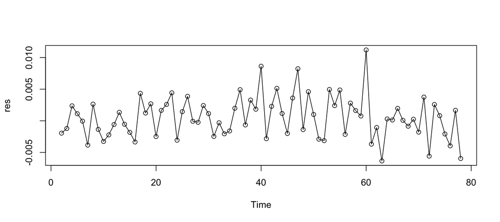

```r
  res <- Fit11$resid                        # extract residuals from the 1st fit
  plot(res, type="o")                       # plot residuals
```

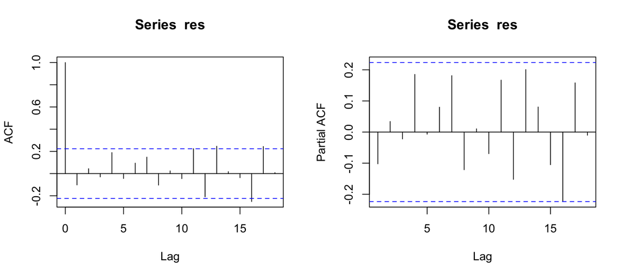

```r
  layout(matrix(1:2, 1,2))                  # 2 plots side by side
  acf(res)                                  # check for autocorrelation in residuals
  pacf(res)
```

```r
  layout(1)                                 # reset the layout
```

# Summary

- To fit AR(p), you must choose with mean or without mean.
- Look at sample ACF and sample PACF to guess p.
- Use minumum Akaike Information Criteria (AIC) criteria to look for the best $p$.
- Check parameter significance of estimated parameters. If the last parameter is not significant, reduce $p$ by 1, and fit again.
- After getting the suggested “best” $p$ from AIC, fit model with p+1, and see if the last parameter estimate comes out non-significant.
- Check residuals for randomness (no-autocorrelation) by plotting reiduals itself, ACF and PACF.

[TS Class Web Page](https://nmimoto.github.io/477/index.html) – [R resource page](https://nmimoto.github.io/R/index.html)